# Introduction to Open Data Science 2022, Assignment 2

Yu Ren

2022-11-10

*Describe the work you have done this week and summarize your learning.* Data wrangling and analysis

- Describe your work and results clearly.
- Assume the reader has an introductory course level understanding of writing and reading R code as well as statistical methods.
- Assume the reader has no previous knowledge of your data or the more advanced methods you are using.

1.read date set

```r
learning2014 <- read.table("https://raw.githubusercontent.com/KimmoVehkalahti/Helsinki-Open-Data-Science/master/datasets/learning2014.txt",
                            sep = ",", header = T)
```

2. Show a graphical overview of the data and show summaries of the variables in the data.

```r
View(learning2014)
dim(learning2014)
```

```
## [1] 166   7
```

```r
str(learning2014)
```

```
## 'data.frame':    166 obs. of  7 variables:
##  $ gender  : chr  "F" "M" "F" "M" ...
##  $ age     : int  53 55 49 53 49 38 50 37 37 42 ...
##  $ attitude: num  3.7 3.1 2.5 3.5 3.7 3.8 3.5 2.9 3.8 2.1 ...
##  $ deep    : num  3.58 2.92 3.5 3.5 3.67 ...
##  $ stra    : num  3.38 2.75 3.62 3.12 3.62 ...
##  $ surf    : num  2.58 3.17 2.25 2.25 2.83 ...
##  $ points  : int  25 12 24 10 22 21 21 31 24 26 ...
```

3.Choose three variables as explanatory variables and fit a regression model where exam points is the target (dependent, outcome) variable. 3.1First, visualize the data set and create a plot matrix with ggpairs()

```r
library(GGally)
```

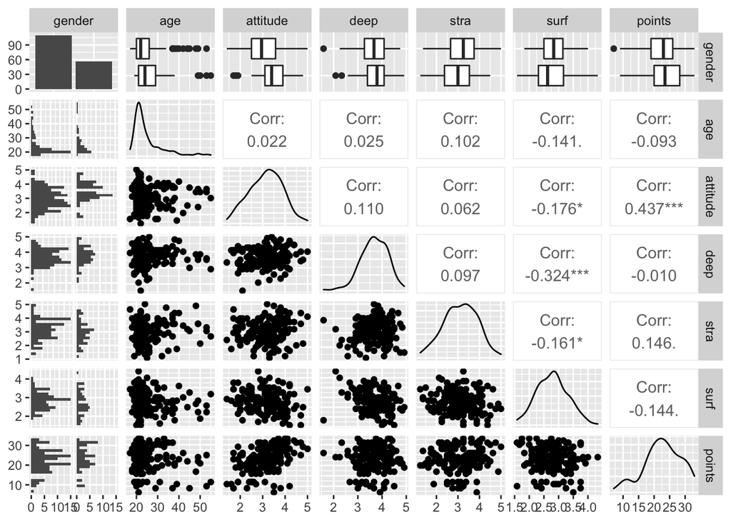

```r
library(ggplot2)
ggpairs(learning2014, lower = list(combo = wrap("facethist", bins = 20)))
```

3.2Choose attitude, points and surf as variables and fit a regression model

```r
fit <- learning2014 %>%
  lm(points ~ attitude + surf, data = .)
summary(fit)
```

```
##
## Call:
## lm(formula = points ~ attitude + surf, data = .)
##
## Residuals:
##     Min      1Q  Median      3Q     Max
## -17.277  -3.236   0.386   3.977  10.642
##
## Coefficients:
##             Estimate Std. Error t value Pr(>|t|)
## (Intercept)  14.1196     3.1271   4.515 1.21e-05 ***
## attitude      3.4264     0.5764   5.944 1.63e-08 ***
## surf         -0.7790     0.7956  -0.979    0.329
## ---
## Signif. codes:  0 '***' 0.001 '**' 0.01 '*' 0.05 '.' 0.1 ' ' 1
##
## Residual standard error: 5.32 on 163 degrees of freedom
## Multiple R-squared:  0.1953, Adjusted R-squared:  0.1854
## F-statistic: 19.78 on 2 and 163 DF,  p-value: 2.041e-08
```

The result shows that expect surf, the p-values for the other variables are both significant and predictive. adjust R-squared shows that the model explains 18.54%.

3.3 remove the variable of surf, and fit the model again.

```r
fit2 <- learning2014 %>%
  lm(points ~ attitude, data = .)
summary(fit2)
```

```
##
## Call:
## lm(formula = points ~ attitude, data = .)
##
## Residuals:
##      Min       1Q   Median       3Q      Max
## -16.9763  -3.2119   0.4339   4.1534  10.6645
##
## Coefficients:
##             Estimate Std. Error t value Pr(>|t|)
## (Intercept)  11.6372     1.8303   6.358 1.95e-09 ***
## attitude      3.5255     0.5674   6.214 4.12e-09 ***
## ---
## Signif. codes:  0 '***' 0.001 '**' 0.01 '*' 0.05 '.' 0.1 ' ' 1
##
## Residual standard error: 5.32 on 164 degrees of freedom
## Multiple R-squared:  0.1906, Adjusted R-squared:  0.1856
## F-statistic: 38.61 on 1 and 164 DF,  p-value: 4.119e-09
```

4.Model diagnostic

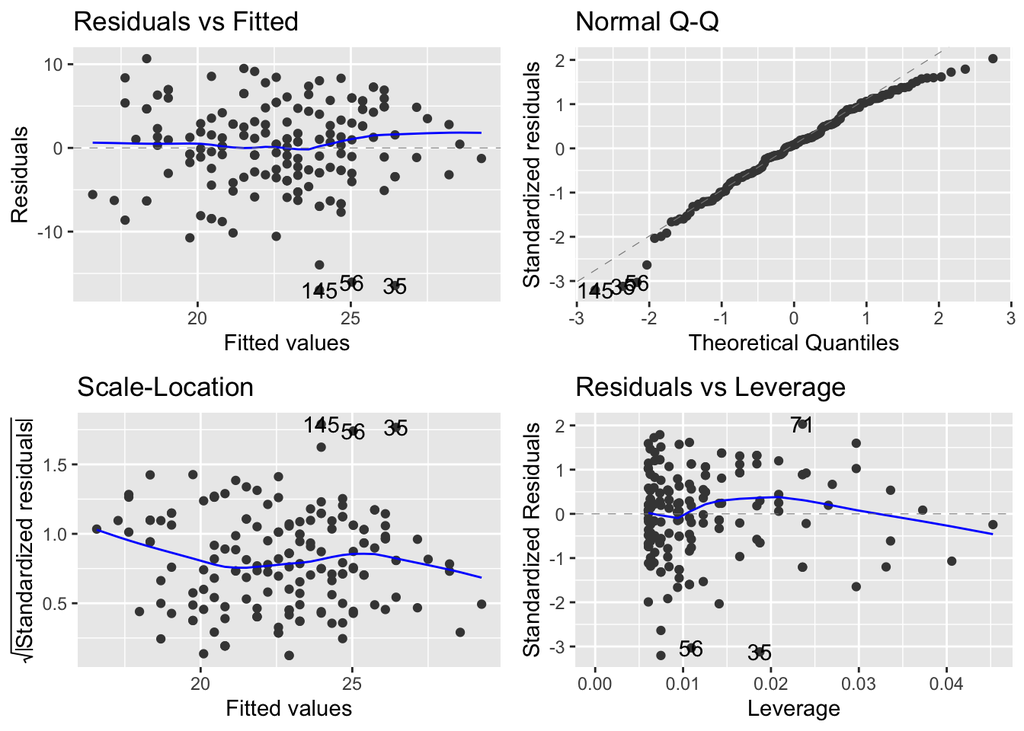

```r
library(ggfortify)
autoplot(fit2)
```

The Residuals vs fitted plot shows the data distributed up and down along the blue line with no clear trend, indicating a linear relationship.